# Elemental Confounders - Phylo-Edition

## Fork: Common Cause as Confounder

We start with the classic Confounder example, where a binary trait $Z$ affects the two continuous traits $X$ and $Y$, which themselves are not having an effect on one another:

[interactive chart not shown]

To simulate this, we can first create the confounder $Z$, by simply simulating a binary trait using an Mk-model:

```r
# define Q matrix with transition rates between states 0 and 1
Q <- matrix(c(-0.2000,  0.2000,
               0.0001, -0.0001),          # Mostly irreversible for simplicity
              byrow=TRUE, nrow=2, ncol=2)
rownames(Q) <- colnames(Q) <- c("0","1")
Q
```

```
##        0      1
## 0 -2e-01  2e-01
## 1  1e-04 -1e-04
```

```r
# simulate trait history using tree and transition rate matrix
set.seed(1234)
Zhistory <- sim.history(tree, Q, anc=setNames(c(1,0), c("0", "1")), direction="row_to_column")
```

```
## Note - the rate of substitution from i->j should be given by Q[i,j].
## Done simulation(s).
```

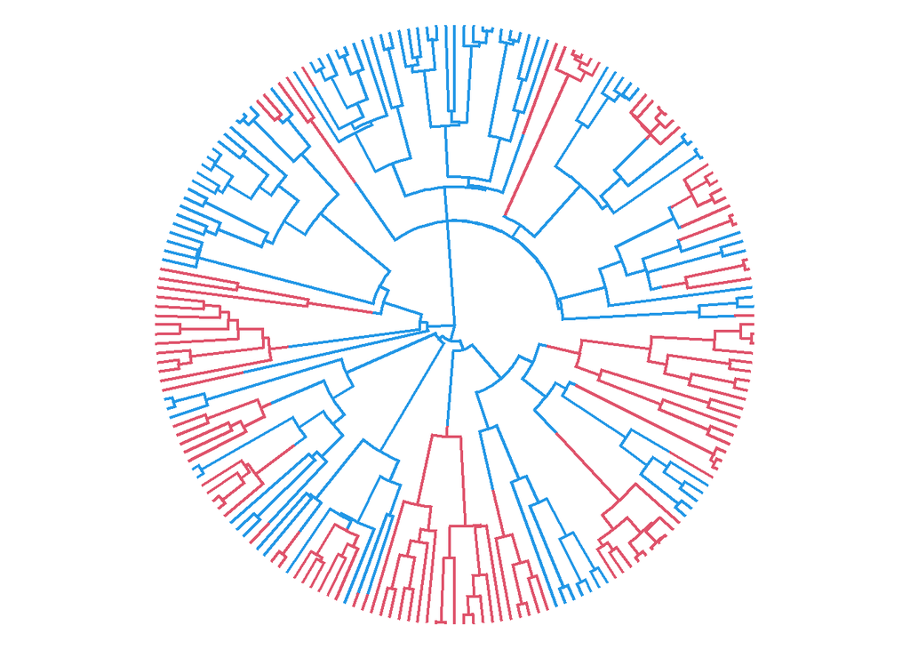

```r
plot(Zhistory, type="fan", ftype="off", colors= setNames(cols, c("0", "1")))
```

```r
# Tip states as named vector
Z <- as.numeric(Zhistory$states)
names(Z) <- Zhistory$tip.label
```

Now we can simulate the continuous traits $X$ and $Y$ using Brownian motion. We let them be affected by $Z$ by simply adding the product of the intended effect size of $Z$ and the respective state of $Z$, i.e., for those with `Z==1` the resulting effect will just be what we set it to (e.g., `-3`), for those with `Z==0` it will be `0`.

```r
# set effect of Z if 1
true_ZonX <- -3
true_ZonY <-  3

sig2 <- 0.1  #sigma2 for BM
X <- true_ZonX * Z + fastBM(tree, sig2)  # X is caused by Z
Y <- true_ZonY * Z + fastBM(tree, sig2)  # Y is caused by Z, no efect of X
```

When we put these variables into a data frame for subsequent use, we can plot them pairwise to get a sense of how they relate to one another:

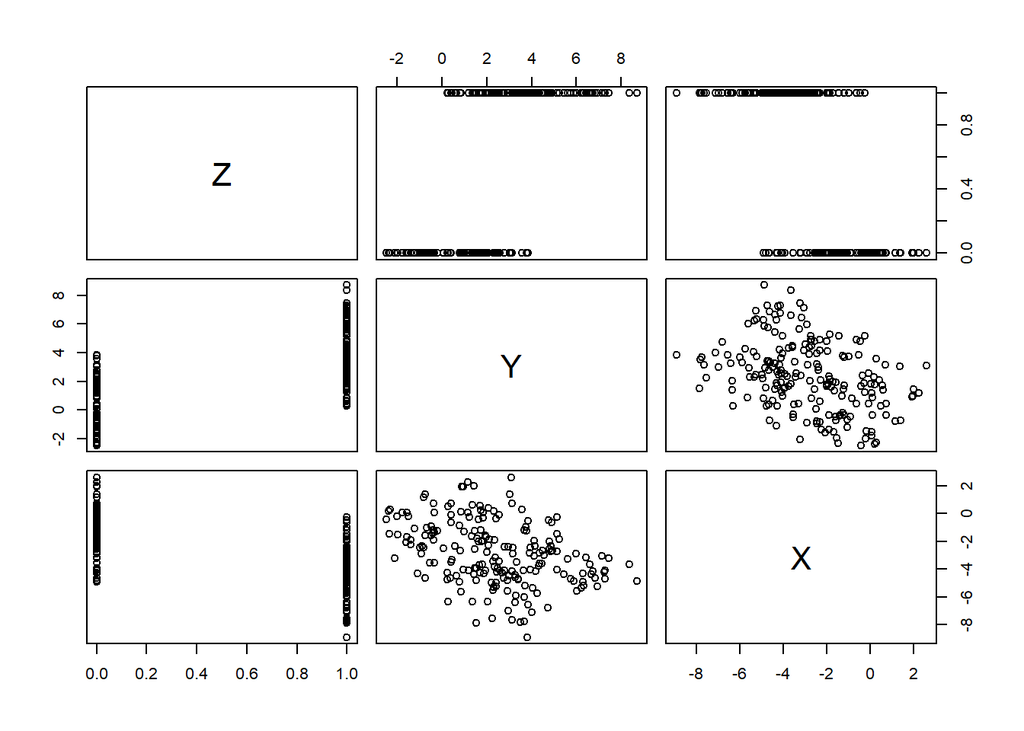

```r
dat_fork <- data.frame("Z"=Z, "Y"=Y, "X"=X)
pairs(dat_fork)
```

Given that we evolved these traits on a tree, we might also want to look at them that way:

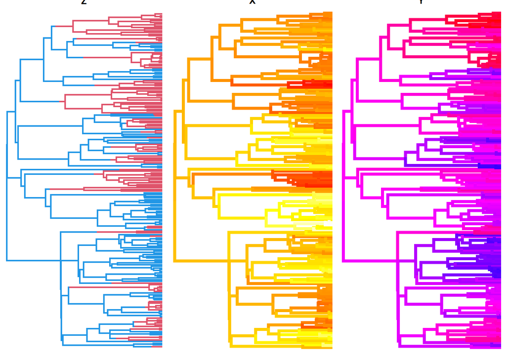

```r
par(mfrow=c(1, 3))
plot(Zhistory, type="phylogram", ftype="off", colors= setNames(cols, c("0", "1")))
title("Z")
plotBranchbyTrait(tree, X, mode=c("tips"), palette="heat.colors", legend=FALSE, show.tip.label=FALSE)
title("X")
plotBranchbyTrait(tree, Y, mode=c("tips"), palette="rainbow", legend=FALSE, show.tip.label=FALSE)
title("Y")
```

Now let’s pretend we this is our actual data and we are interested whether there is any association between $X$ and $Y$ (or even a causal effect). We know the shared evolutionary history could bias a regular regression, so we run a PGLS:

```r
# run PGLS on them
naive <- phylolm(Y~X, dat_fork, tree, model="BM")
summary(naive)  # X falsely significant
```

```
##
## Call:
## phylolm(formula = Y ~ X, data = dat_fork, phy = tree, model = "BM")
##
##    AIC logLik
##  557.6 -275.8
##
## Raw residuals:
##     Min      1Q  Median      3Q     Max
## -4.7017 -1.6838 -0.2418  1.5817  5.6173
##
## Mean tip height: 3.749077
## Parameter estimate(s) using ML:
## sigma2: 1.184912
##
## Coefficients:
##             Estimate   StdErr t.value   p.value
## (Intercept)  1.68583  0.63852  2.6402  0.008945 **
## X           -0.28880  0.06046 -4.7767 3.464e-06 ***
## ---
## Signif. codes:  0 '***' 0.001 '**' 0.01 '*' 0.05 '.' 0.1 ' ' 1
##
## R-squared: 0.1033    Adjusted R-squared: 0.0988
```

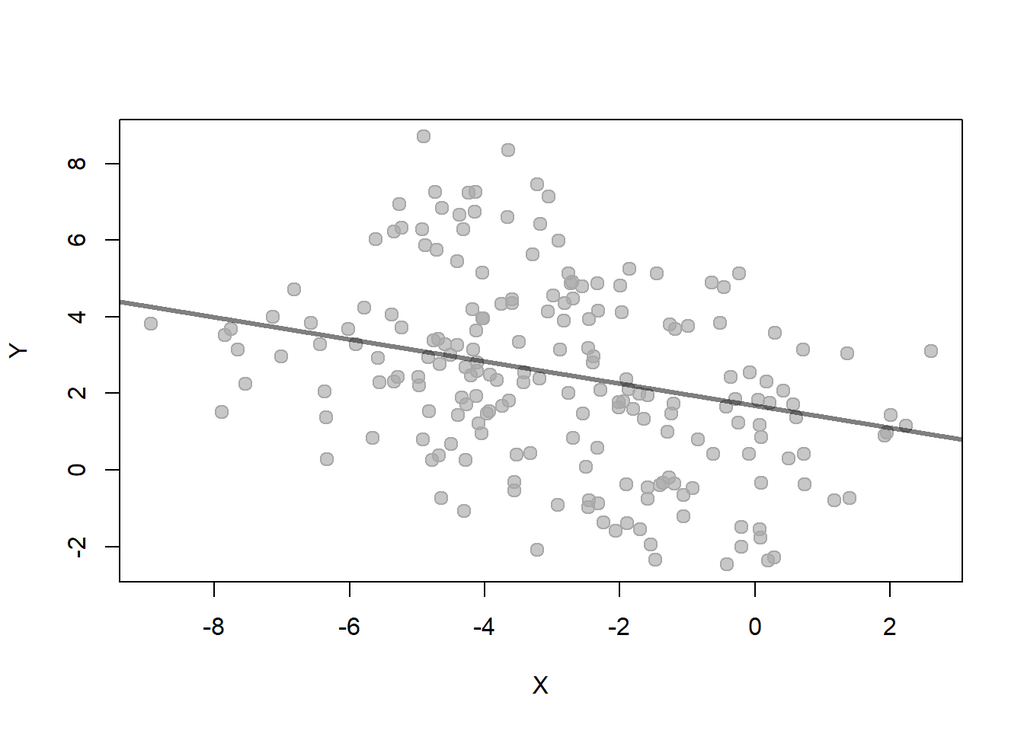

```r
# plot data with fitted line
plot(X, Y, col=alpha("darkgray", 1), bg=alpha("darkgray", 0.65), pch=21, cex=1.25, lwd=1)
abline(naive, col=alpha("black", 0.5), lwd=3)
```

The results seem to indicate that there is a significant negative effect of $X$ on $Y$ (or at least a negative association), and plotting the data with the regression line makes this seem legit.

[*You may note that the regression line doesn’t quite go through the points as you might expect. This is the effect of the phylogenetically structured residuals. If you were to run a regular regression (`lm(Y~X)`), it would (falsely) infer a stronger association.*]

But we *know* that $X$ doesn’t have an effect on $Y$, because we simulated them! How does this make sense? Let’s say we’re aware of the trait $Z$ in these species and - because of our knowledge of their biology - we suspect that $Z$ may be involved in the evolution of the other traits. So we include it in the regression:

```r
strat <- phylolm(Y~X+Z, dat_fork, tree, model="BM")
summary(strat)  # Z significant (and almost right), X not anymore
```

```
##
## Call:
## phylolm(formula = Y ~ X + Z, data = dat_fork, phy = tree, model = "BM")
##
##    AIC logLik
##  513.2 -252.6
##
## Raw residuals:
##     Min      1Q  Median      3Q     Max
## -3.3143 -1.2018  0.1745  1.2264  5.3273
##
## Mean tip height: 3.749077
## Parameter estimate(s) using ML:
## sigma2: 0.9392887
##
## Coefficients:
##             Estimate   StdErr t.value   p.value
## (Intercept) 0.851724 0.581666  1.4643    0.1447
## X           0.015834 0.068657  0.2306    0.8178
## Z           2.600260 0.362283  7.1774 1.414e-11 ***
## ---
## Signif. codes:  0 '***' 0.001 '**' 0.01 '*' 0.05 '.' 0.1 ' ' 1
##
## R-squared: 0.2892    Adjusted R-squared: 0.282
```

Now $Z$ is significantly assoicated with $Y$, but $X$ suddenly isn’t anymore! Let’s plot the data again and see what’s happening, by colouring the points by their state of $Z$ and comparing the new regression lines.

We can actually plot the separate fits for both states of $Z$ quite easily. As in the naive run, the intercept is the value of $Y$ when $X$ is `0`. The estimated coefficient for a binary $Z$ is the difference of means between the two groups in $Z$ (`0` and `1`), so we can treat it as the difference in intercept between the groups:

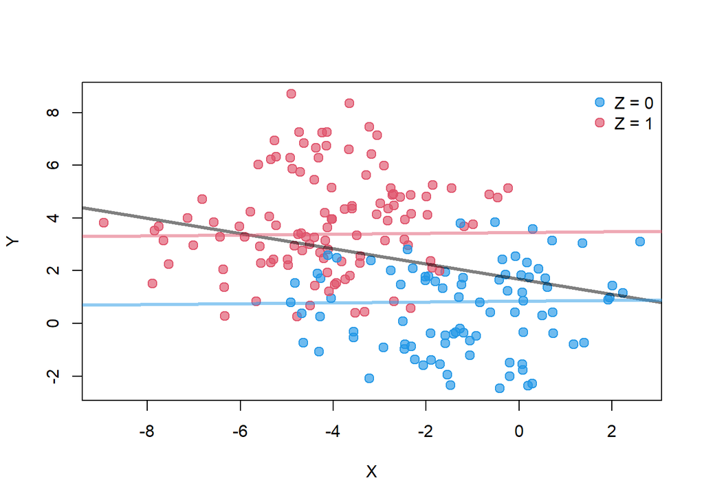

```r
# plot naive fit again, but with points colored by their Z-value
plot(X, Y, col=alpha(cols[Z+1], 1), bg=alpha(cols[Z+1], 0.65), pch=21, cex=1.25, lwd=1)
legend("topright", legend=c("Z = 0", "Z = 1"), pch=c(21, 21), col=alpha(cols, 1), pt.bg=alpha(cols, 0.65), cex=1, pt.cex=1.25, bty='n')
abline(naive, col=alpha("black", 0.5), lwd=3)
abline(strat$coefficients[1], strat$coefficients[2], col=alpha(cols[1], 0.5), lwd=3)
abline(strat$coefficients[1]+strat$coefficients[3], strat$coefficients[2], col=alpha(cols[2], 0.5), lwd=3)
```

We can actually see here now how exactly $Z$ confounded the naive analysis and created the spurious association between $X$ and $Y$: While both evolved under independent Brownian motion processes, all species for which $Z$ is present (i.e., `Z==1`) have their values for $X$ shifted down by `true_ZonX`. Meanwhile, the same species have their values for $Y$ shifted up by `true_XonY`. So all species with `Z==1` have now exeptionally *low* values for $X$ and exeptionally *high* values for $Y$, thus creating the negative association. However, within both groups (`Z==0` and `Z==1`), there is still no association between $X$ and $Y$.

So what does this mean? The *association* between the two traits is not wrong: Species with lower values of $X$ *do* have higher values for $Y$. However, this association is not because of a *causal relation* between $X$ and $Y$, but simply because they share the *Common Cause* $Z$. By including $Z$ in the regression, we *condition* on it, i.e., we ‘filter’ the effect of $Z$ out of the estimate of the effect of $X$, by estimating both separately. Hence we get a separate intercept for the two states of $Z$ but the same slope for $X$. Conceptually, by including $Z$, we blocked that path, so no information can flow between $X$ and $Y$ anymore unless it goes through a direct connection between them (or an indirect one that doesn’t include $Z$).

Let’s try the same for the other Confounders!

## Pipe: Mediator

The Pipe is one of the simplest scenarios, where the causal effects are ‘daisychained’: the (in our case) continous trait $X$ affects the binary trait $Z$, which in turn affects the continuous trait $Y$. In this case we call $Z$ a *Mediator*, because it essentially ‘passes’ the effect of $X$ on to $Y$.

[interactive chart not shown]

Again, we can simulate this. This time we first create an independent $X$ using BM. Then we make a $Z$ dependent on $X$ by ‘thresholding’ it, i.e., we make $Z$ be `1` for high values of $X$. Finally, we make the continuous $Y$ dependent on $Z$ like we did above.

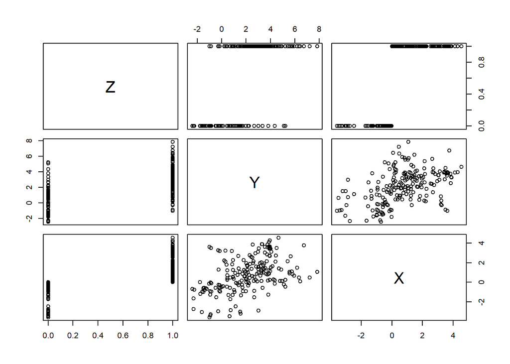

```r
# make continuous X
sig2 <- 0.1
X <- fastBM(tree, sig2)  # X is independent
# make binary Z by 'thresholding' X (as per Liam Revell: https://blog.phytools.org/2024/05/fitting-and-analyzing-threshold-model.html)
thresh <- function(X) if(X<0) 0 else 1  # positive X means Z=1
Z <- sapply(X, thresh)  # Z is caused by X
# make continuous Y
Y <- true_ZonY * Z + fastBM(tree, sig2)  # Y is caused by Z

# get history for Z for later plotting
Zfit <- fitMk(tree, Z, model="ARD")
anc_Z <- ancr(Zfit)

# put variables into data frame an plot pairwise comparison
dat_pipe <- data.frame("Z"=Z, "Y"=Y, "X"=X)
pairs(dat_pipe)
```

Again, we can look at the resulting traits on the tree if we want.

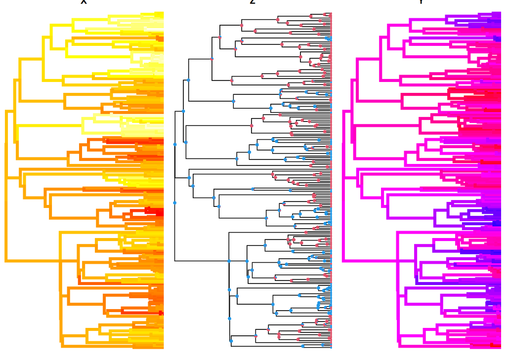

```r
par(mfrow=c(1, 3))
plotBranchbyTrait(tree, X, mode=c("tips"), palette="heat.colors", legend=FALSE, show.tip.label=FALSE)
title("X")
plot(tree, show.tip.label=FALSE)
plot(anc_Z,
  args.plotTree=list(type="phy", ftype="off"),
  args.nodelabels=list(piecol=cols,cex=0.5),
  args.tiplabels=list(cex=0.3),
  legend=FALSE)
title("Z")
plotBranchbyTrait(tree, Y, mode=c("tips"), palette="rainbow", legend=FALSE, show.tip.label=FALSE)
title("Y")
```

We take the naive stance first again and run a PGLS regressing $X$ on $Y$:

```r
# run PGLS on them
naive <- phylolm(Y~X, dat_pipe, tree, model="BM")
summary(naive)  # X correctly significant
```

```
##
## Call:
## phylolm(formula = Y ~ X, data = dat_pipe, phy = tree, model = "BM")
##
##    AIC logLik
##  803.4 -398.7
##
## Raw residuals:
##     Min      1Q  Median      3Q     Max
## -5.3550 -1.3774 -0.3457  0.7903  5.2645
##
## Mean tip height: 3.749077
## Parameter estimate(s) using ML:
## sigma2: 4.04985
##
## Coefficients:
##             Estimate  StdErr t.value   p.value
## (Intercept)  1.82543 1.14467  1.5947    0.1124
## X            0.69930 0.14641  4.7763 3.469e-06 ***
## ---
## Signif. codes:  0 '***' 0.001 '**' 0.01 '*' 0.05 '.' 0.1 ' ' 1
##
## R-squared: 0.1033    Adjusted R-squared: 0.09879
```

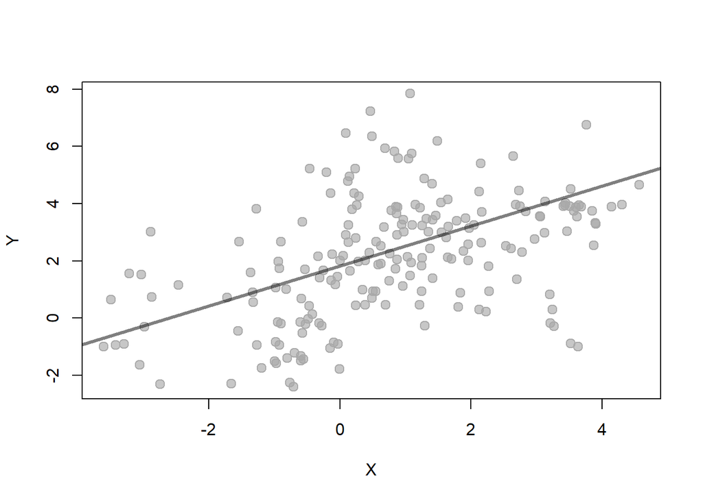

```r
# plot data with fitted line
plot(X, Y, col=alpha("darkgray", 1), bg=alpha("darkgray", 0.65), pch=21, cex=1.25, lwd=1)
abline(naive, col=alpha("black", 0.5), lwd=3)
```

We get a significant relation, as we would expect, since we simulated $X$ to have a positive effect on $Y$ (via $Z$). So far so good.

But if we have reason to believe that $Z$ is involved in this process, perhaps we get a more accurate or realistic result by including it in our regression?

```r
strat <- phylolm(Y~X+Z, dat_pipe, tree, model="BM")
summary(strat)  # Z significant (and almost right), X not anymore
```

```
##
## Call:
## phylolm(formula = Y ~ X + Z, data = dat_pipe, phy = tree, model = "BM")
##
##    AIC logLik
##  544.4 -268.2
##
## Raw residuals:
##     Min      1Q  Median      3Q     Max
## -4.3600 -1.3783 -0.2586  0.6522  4.8014
##
## Mean tip height: 3.749077
## Parameter estimate(s) using ML:
## sigma2: 1.097921
##
## Coefficients:
##               Estimate     StdErr t.value p.value
## (Intercept)  0.4124344  0.6006589  0.6866  0.4931
## X           -0.0025933  0.0822850 -0.0315  0.9749
## Z            2.9661977  0.1288842 23.0144  <2e-16 ***
## ---
## Signif. codes:  0 '***' 0.001 '**' 0.01 '*' 0.05 '.' 0.1 ' ' 1
##
## R-squared: 0.7569    Adjusted R-squared: 0.7544
```

Unsurprisingly, $Z$ comes out as significant - but now $X$ suddenly isn’t significant anymore? Let’s plot this coloured by $Z$ and with separate regression lines again, to see what’s going on!

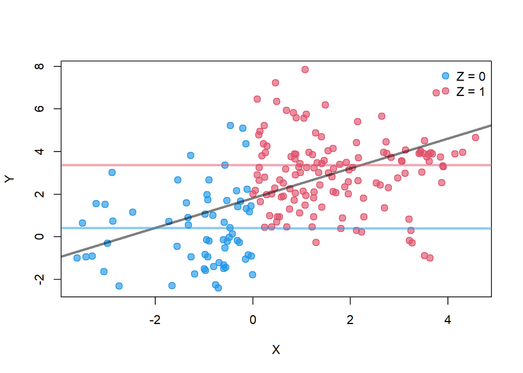

```r
# plot naive fit again, but with points colored by their Z-value
plot(X, Y, col=alpha(cols[Z+1], 1), bg=alpha(cols[Z+1], 0.65), pch=21, cex=1.25, lwd=1)
legend("topright", legend=c("Z = 0", "Z = 1"), pch=c(21, 21), col=alpha(cols, 1), pt.bg=alpha(cols, 0.65), cex=1, pt.cex=1.25, bty='n')
abline(naive, col=alpha("black", 0.5), lwd=3)
abline(strat$coefficients[1], strat$coefficients[2], col=alpha(cols[1], 0.5), lwd=3)
abline(strat$coefficients[1]+strat$coefficients[3], strat$coefficients[2], col=alpha(cols[2], 0.5), lwd=3)
```

Clearly the effect of $X$ on $Y$ seems to be absent within the two groups of $Z$. But we simulated it so that large $X$ lead to ‘large’ $Z$ which in turn lead to large $Y$. What happened here?

If you recall the logic from above, by including $Z$ in the regression we *condition* on it, meaning we fitting the regression assuming the two states of $Z$ have separate means, i.e., a common slope, but two separate intercepts. By doing so, we ‘filter’ the effect of $Z$ out, leaving only the direct effect of $X$ on $Y$ within each state of $Z$. But the *whole* effect of $X$ on $Y$ goes *through* $Z$, so if we filter out $Z$ we filter out the effect of $X$ with it! In other words, we again block the path through $Z$ by including it, which just as in the case of the Fork means that we disallow the flow of information between $X$ and $Y$. The difference being that unlike above, where we blocked a connection that went *against* the direction of the arrows (and thus was not representing the causal relations), we here block the connection along the actual causal path that represents the actual causal relations.

## Collider: common effect

Finally, the Collider is the counterpart to the Fork, where two independent continuous traits, $X$ and $Y$, both separately affect the binary trait $Z$. While this seems more innocuous, you may find this to be the most upsetting confounder of the three (and we’re about to see why)!

[interactive chart not shown]

We first simulate two independent BM traits for $X$ and $Y$, and then a binary trait $Z$ that is affected by both of them. The way we chose to do this here is by making a dummy trait that combines the values of $X$ and $Y$ first, and by then thresholding that.

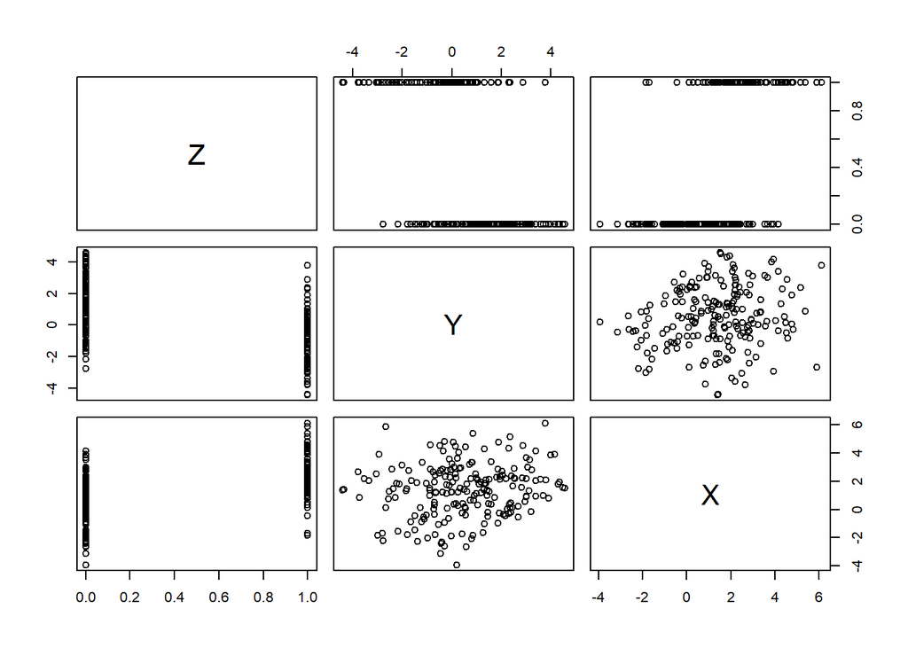

```r
# make continuous X and Y
sig2 <- 0.2
set.seed(3456789)
X <- fastBM(tree, sig2)  # X is independent
Y <- fastBM(tree, sig2)  # Y is independent
# threshold dummy trait
XY <- (X-mean(X))-(Y-mean(Y))  # center traits to avoid imbalance of positive/negative combos
thresh <- function(XY) if(XY<0) 0 else 1 # high X and low Y lead to Z=1
Z <- sapply(XY, thresh)  # Z is caused by X and Y

# get history for Z for later plotting
Zfit <- fitMk(tree, Z, model="ARD")
anc_Z <- ancr(Zfit)

# put variables into data frame an plot pairwise comparison
dat_coll <- data.frame("Z"=Z, "Y"=Y, "X"=X)
pairs(dat_coll)
```

If we want, we can look at those on the tree again:

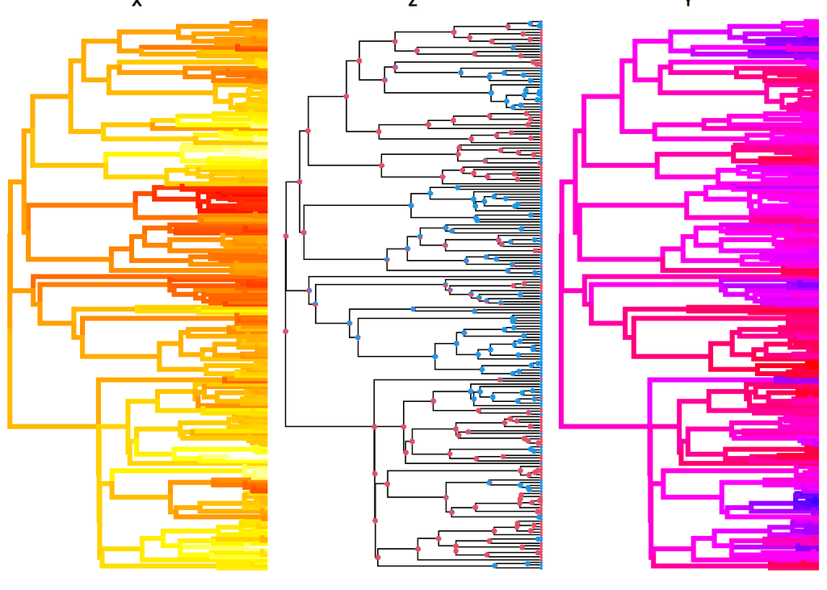

```r
par(mfrow=c(1, 3))
plotBranchbyTrait(tree, X, mode=c("tips"), palette="heat.colors", legend=FALSE, show.tip.label=FALSE)
title("X")
plot(tree, show.tip.label=FALSE)
plot(anc_Z,
  args.plotTree=list(type="phy", ftype="off"),
  args.nodelabels=list(piecol=cols,cex=0.5),
  args.tiplabels=list(cex=0.3),
  legend=FALSE)
title("Z")
plotBranchbyTrait(tree, Y, mode=c("tips"), palette="rainbow", legend=FALSE, show.tip.label=FALSE)
title("Y")
```

Once again we run the naive PGLS on $X$ and $Y$, which we’d now expect to show no relation.

```r
# run PGLS on them
naive <- phylolm(Y~X, dat_coll, tree, model="BM")
summary(naive)  # X correctly not significant
```

```
##
## Call:
## phylolm(formula = Y ~ X, data = dat_coll, phy = tree, model = "BM")
##
##    AIC logLik
##  546.9 -270.5
##
## Raw residuals:
##     Min      1Q  Median      3Q     Max
## -5.1035 -1.3336 -0.1689  1.1834  3.8733
##
## Mean tip height: 3.749077
## Parameter estimate(s) using ML:
## sigma2: 1.123026
##
## Coefficients:
##             Estimate  StdErr t.value p.value
## (Intercept)  0.53978 0.60380  0.8940  0.3724
## X            0.10728 0.07301  1.4694  0.1433
##
## R-squared: 0.01079   Adjusted R-squared: 0.005791
```

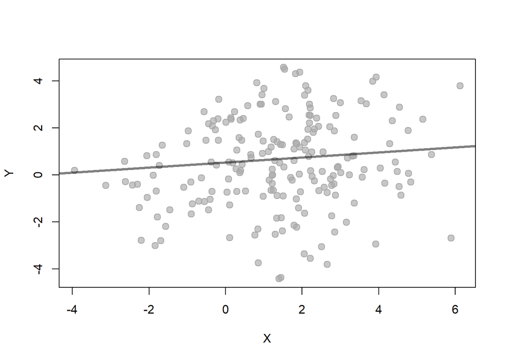

```r
# plot data with fitted line
plot(X, Y, col=alpha("darkgray", 1), bg=alpha("darkgray", 0.65), pch=21, cex=1.25, lwd=1)
abline(naive, col=alpha("black", 0.5), lwd=3)
```

This seems to look as expected, and we could rightly conclude that there’s no relation between $X$ and $Y$. But perhaps our knowledge of the biology of these taxa again made us realise that $Z$ might play a role here, so we decide to include it as well.

```r
strat <- phylolm(Y~X+Z, dat_coll, tree, model="BM")
summary(strat)  # Z significant , X falsely as well
```

```
##
## Call:
## phylolm(formula = Y ~ X + Z, data = dat_coll, phy = tree, model = "BM")
##
##    AIC logLik
##  532.3 -262.1
##
## Raw residuals:
##     Min      1Q  Median      3Q     Max
## -4.8266 -1.2441 -0.1812  0.9433  3.6586
##
## Mean tip height: 3.749077
## Parameter estimate(s) using ML:
## sigma2: 1.033264
##
## Coefficients:
##              Estimate    StdErr t.value   p.value
## (Intercept)  0.657644  0.581331  1.1313   0.25932
## X            0.171093  0.071884  2.3801   0.01826 *
## Z           -0.483850  0.116959 -4.1369 5.211e-05 ***
## ---
## Signif. codes:  0 '***' 0.001 '**' 0.01 '*' 0.05 '.' 0.1 ' ' 1
##
## R-squared: 0.08985   Adjusted R-squared: 0.08061
```

Now $Z$ is significantly associated with $Y$, as we might expect, since we simulated one to be depending on the other. However, now $X$ suddenly has a significant effect too! How is this possible, when we simulated them as independent from one another? In case of the Fork above, this made intuitive sense, because $Z$ connected the other two causally by having an effect on both, but here the causal relation goes the other way, so $X$ shouldn’t pass information from $Y$ on to $Y$?

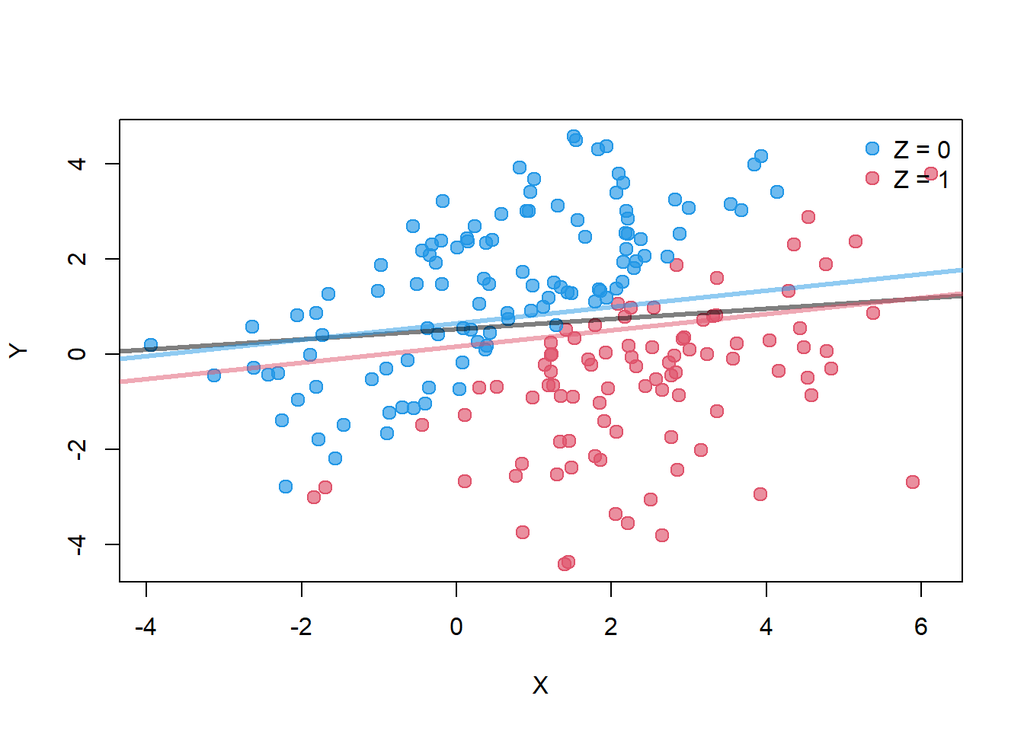

```r
# plot naive fit again, but with points colored by their Z-value
plot(X, Y, col=alpha(cols[Z+1], 1), bg=alpha(cols[Z+1], 0.65), pch=21, cex=1.25, lwd=1)
legend("topright", legend=c("Z = 0", "Z = 1"), pch=c(21, 21), col=alpha(cols, 1), pt.bg=alpha(cols, 0.65), cex=1, pt.cex=1.25, bty='n')
abline(naive, col=alpha("black", 0.5), lwd=3)
abline(strat$coefficients[1], strat$coefficients[2], col=alpha(cols[1], 0.5), lwd=3)
abline(strat$coefficients[1]+strat$coefficients[3], strat$coefficients[2], col=alpha(cols[2], 0.5), lwd=3)
```

The plot of the separate regression lines helps clarify this a little. As we can see, the distribution of $Z$ within the point cloud of $X$ and $Y$ is such that there is a positive relation between them in both states, despite there being none overall. This makes sense given the simulation: if high values of $X$ lead to $Z$ being `1` and low values of $Y$ do the same, we get a pattern where the data is split ‘diagonally’ according to the combination of $X$ and $Y$.

This effect can be behind the phenomemon of how the significance of variables in a regression can seemingly change randomly depending on which ones we include. This is also what can cause problems if we e.g., gradually include or exclude variables until we get a set where all are significant. Thinking about the causal structure in the data (i.e., the causal process that generated it) can help us see through those issues!

## Chose your own adventure

Now that you know these different confounders, the effects they have, and how to simulate the corresponding data, try and come up with your own confounded examples. This can be variations on the above examples, or extensions of them, e.g., where more variables are involved.

For example: What if you have a Common Cause confounder as in the Fork example above, but $X$ still also has an effect on $Y$?

1. What would the DAG look like?
2. How do you simulate the example data with all the intended effects (pay attention to the order based on the arrows)?
3. Which way of setting up the analysis do you expect to give you the more accurate result?

In these cases, also focus more on how well the inferred effect matches the simulated one!

[Feel free to show me what you came up with!]